# How to Use rFreight

# 5 Common Pitfalls

- sampling 1 thing (or number)
- data type confusion: factor, character, numeric

# 6 Best Practices

The following sections detail a number of best practices for developing applications using `rFreight`. Such applications can be intense in terms of computation, code complexity, and file storage. Code and files that are self-documenting and “DRY” are critical to the success of rFreight applications from both a user and developer perspective, and tend to produce higher performing applications in terms of speed, flexibility, and accessibility.

In general, it is recommended developers author code with a consistent style to ensure readability and easy transference between developers. Google’s [R Style Guide](https://google.github.io/styleguide/Rguide.xml) provides comprehensive guidance on good code style, covering topics such as spacing, indentation, and use of curly braces.

While it is strongly recommended that developers of `rFreight` applications adhere to the conventions detailed in the following sections as often as is feasible, they are not absolute rules and may be modified to suit the needs of a particular project or situation. So long as the spirit of these best practices are followed, the exact implementation need not be defined too strictly.

## 6.1 Software and Package Versions

## 6.2 Source Control

- GitHub & LFS (install both; latest versions)
- How to clone the repository
- Report issues! Add “TODO: Issue #11”
- Advanced: Shell commands
- All else fails: xkcd comic

## 6.3 Self-Documenting Code

Self-documenting code is an authoring style that produces code that can be followed and understood by those unfamilar with the application or by the original author at a future time when their memory of the application details has faded. It is characterized by detailed code comments and long variable names (e.g., a variable named `TimeOfDay` rather than `x` or `tod`). Self-documenting code and files enable a developer to revisit their application months or years in the future and be better able to navigate the details and nuances of the code without having retained all knowledge of the details since they last worked with it. Similarly, self-documentation facilitates collaboration between developers as they are better able to understand each other’s work and intent.

Such an approach also conducive to spotting errors, as the original author’s intent is embedded alongside the code or file. Consider the following line of code:

```r
x<-18
```

What is this line trying to do? Is it attempting to test whether `x` is less than -18 or is it attempting to assign 18 to `x`? Regardless of what the code actually does (it assigns 18 to `x`), a reviewer of this code cannot infer the intent of the original author. Now consider the following, self-documenting code:

```r
# Establish the age threshold of an adult
AdultAge<-18
```

The addition of the author’s comment and the more descriptive variable name `AdultAge` makes for a more verbose block of code, but the intent is clear. A reviewer is now able to determine that the original author is probably attempting to assign the value 18 to the variable `AdultAge`, as this makes the most sense given the comment. They are then able to test whether the code matches this intent. In this case, it does. Though, better coding style would have white space around the assignment operator `AdultAge <- 18` (see [R Style Guide](https://google.github.io/styleguide/Rguide.xml)).

The following sections provide guidance for naming variables, files, and functions.

### 6.3.1 Variable Naming Conventions

Creating names for variables is the most common task an `rFreight` application developer is required to perform. An application may require many dozens or even hundreds of objects to be defined, so having descriptive (but succinct) and consistent (but distinguishable) object names goes a long way toward self-documentation. Object names longer than about 30 characters can become unwieldy to code with, and creating descriptive names with fewer than 30 characters can be challenging at times. With thoughtful consideration, practice, and examples, the challenge is not insurmountable. In all circumstances, an object’s name should reflect its contents.

**R** object names are case sensitive and must begin with a letter (i.e. a-z or A-Z), but may otherwise contain numbers (1-9), periods (`.`), and underscores (`_`), even as the last character. However, it is recommended that names be created using CamelCase. Each word of the variable name is capitalized rather than being separated with an underscore or period. For example, `ScheduledTrips` is preferred over `scheduledtrips`, `scheduled_trips`, and `scheduled.trips`. Because **R** is case sensitive, a common error to avoid is the miscapitalization of an object name:

```r
MyVariable <- "Hello World!"
print(MYVariable) # returns an error
```

```
## Error in print(MYVariable): object 'MYVariable' not found
```

Periods are typically reserved to designate an object’s structure. For example, `ScheduledTrips.List` and `ScheduledTrips.Matrix` clearly tells us the contents and structure of the data. Underscores are typically reserved for system, scenario, and user variables (see the System, Scenario, and User Variables section).

It is possible to include non-standard characters in an object name (e.g., `&`, `$`, ` `), by surrounding the name in back-ticks `` `` ``. This should be avoided in most circumstances but can be useful for providing custom variable names to other work flows, such as saving a table to a CSV file or as a shortcut for plotting data with more readable labels:

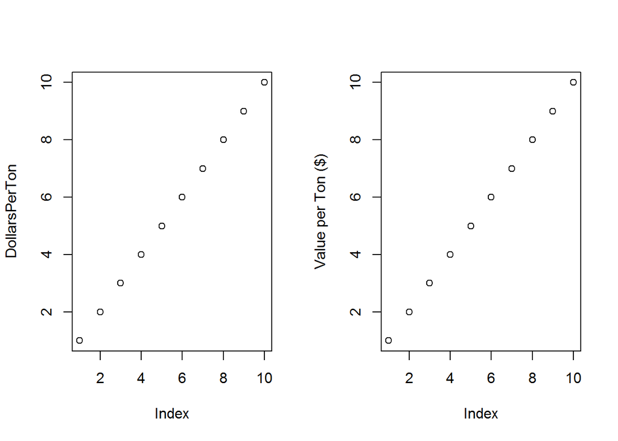

```r
# Original name
DollarsPerTon <- 1:10

# Custom name
`Value per Ton ($)` <- 1:10

par(mfrow = c(1,2))
plot(DollarsPerTon)
plot(`Value per Ton ($)`)
```

When naming a `data.frame` or `data.table`, its name should reflect the observational unit of its rows. If a dataset contains a list of firms and their attributes (e.g., number of employees, location, etc.), the following names would serve as self-documenting:

```r
# Good Variable Names
Firms
Business
Establishments
```

While these are not:

```r
# Poor Variable Names
Bus
Est
agents
```

Notice that `agents` is a poor variable name. While individual firms may act as the primary agent in a simulation, the term “agent” on its own is not informative as to what information is contained in the object.

### 6.3.2 File Naming Conventions

### 6.3.3 Function Naming Conventions

## 6.4 “DRY” Code

“DRY” code (Don’t Repeat Yourself), is a code authoring philosophy that seeks to minimize repeated code. Repeating code invites frustration on the part of developers and users alike, reduces flexibility, and lowers performance. Frustration ensues when errors are discovered in repeated code, and every instance of the repeated code must be corrected, requiring more time to make corrections and possibly introducing errors with each correction (or missing a repeated piece of code that needs to be corrected).

- typing numbers other than 0 or 1

## 6.5 Data Storage

### 6.5.1 Data Types

- characters/numeric twice as large as integer/factor/logical
- exception: table IDs -> should be integer not factor (unnecessary)
- Can avoid logical if you want (write out is trickier)
- ID variables
- as.integer > 1 vs. as.integer > 1L

## 6.6 Using the `data.table` Package

The `data.table` package is strongly recommended for building `rFreight` applications. It enables faster and more memory efficient calculations on datasets (called `data.table`s when using the `data.table` package), and the speed and efficiency only increases with the size of the dataset. Given the average size of the datasets used and constructed by the typical `rFreight` application, it is very beneficial and often absolutely critical to implement the simulation code using `data.table` syntax. The following sections provide general guidance and make note of common pitfalls and tips for writing good `data.table` code. See the package help files for more detailed documentation (`help(package = "data.table")` or `?data.table`). Better yet, complete the [data.table course on DataCamp.com](https://www.datacamp.com/courses/data-table-data-manipulation-r-tutorial)

It should first be noted that the primary output of the `data.table` package are objects of class `data.table`. These are simply `data.frame`s in base **R** that have improved methods for subsetting, assignment, grouping, and joining/merging datasets. The most visible of these is the `print` method.

```r
# Create a data.table with 1000 rows
DT <- data.table(X = 1:1000,
                 Y = sample(LETTERS, size = 1000, replace = TRUE),
                 Z = rnorm(1000))
DT # same as print(DT)
```

```
##          X Y           Z
##    1:    1 C -0.04584063
##    2:    2 U -0.18244626
##    3:    3 P -0.23704071
##    4:    4 J  0.06852580
##    5:    5 Z -0.05066475
##   ---
##  996:  996 F  0.54100118
##  997:  997 F  0.43463280
##  998:  998 Y -1.10713326
##  999:  999 P  1.71471393
## 1000: 1000 J -1.26552431
```

Rather than printing up to the first 10,000 rows as `print.data.frame` does, only the first and last five rows are printed by default. Like any function, this behavior can be adjusted by calling the `print` method directly with optional arguments (specifically, `topn` will change the number of rows printed).

This makes examining the contents of a dataset a bit easier, but the real power of `data.table` can be found in the methods for subsetting, assignment, grouping, and joining/merging datasets.

### 6.6.1 The Basics: `i`, `j`, `by`

The improved methods included in the `data.table` package are accessed via very different syntax than that used with `data.frame`s in base **R*. Again, please see the package help files for more detailed documentation, but the general format for working in a data.table is the following:

```r
DT[i, j, by]
```

Where `DT` is a `data.table` object, `i` is row subsetting logic, `j` is a selection or assignment of variables, and `by` is a collection of grouping variables. In each of these, the variables of `DT` can be accessed directly without using strings.

To subset `DT` by `X < 3`:

```r
DT[X < 3]
```

```
##    X Y           Z
## 1: 1 C -0.04584063
## 2: 2 U -0.18244626
```

Note that `X` is referred to directly without quotes. Subsetting logic can be as complex as desired and can reference objects outside of `DT`:

```r
myLetters <- c("R", "S", "G")
DT[X < 50 & Y %in% myLetters]
```

```
##     X Y          Z
## 1:  8 G  2.3854619
## 2: 13 S -1.3201258
## 3: 18 R  0.8673810
## 4: 29 R  1.0220150
## 5: 31 S  2.4311477
## 6: 41 R  0.2317799
## 7: 42 S  0.9286014
## 8: 47 G -0.3280752
```

To select just the `X` and `Y` columns from `DT`, a list of variables is provided in `j`. Note that in `data.table`, the `.` is an alias for the `list` function and should be used when readability is required (almost always):

```r
DT[, .(X, Y)]
```

```
##          X Y
##    1:    1 C
##    2:    2 U
##    3:    3 P
##    4:    4 J
##    5:    5 Z
##   ---
##  996:  996 F
##  997:  997 F
##  998:  998 Y
##  999:  999 P
## 1000: 1000 J
```

Selected variables can be renamed on-the-fly by providing a named list in `j` (e.g., `DT[, .(NewX = X, NewY = Y)]`).

Variables can also be assigned in `j` by using the `:=` operator. This operator is distinctly different from the `<-` and `=` operators in base **R** and only works in `data.table`s:

```r
DT[, NewVariable := X * Z]
DT
```

```
##          X Y           Z   NewVariable
##    1:    1 C -0.04584063 -4.584063e-02
##    2:    2 U -0.18244626 -3.648925e-01
##    3:    3 P -0.23704071 -7.111221e-01
##    4:    4 J  0.06852580  2.741032e-01
##    5:    5 Z -0.05066475 -2.533238e-01
##   ---
##  996:  996 F  0.54100118  5.388372e+02
##  997:  997 F  0.43463280  4.333289e+02
##  998:  998 Y -1.10713326 -1.104919e+03
##  999:  999 P  1.71471393  1.712999e+03
## 1000: 1000 J -1.26552431 -1.265524e+03
```

It is possible to assign multiple variables at the same time, but this is rarely necessary and is not covered here.

Functions can be performed on groups of rows easily in `data.table` with `by`. Such functions could be simple aggregating functions (e.g., `mean` or `sum`) or as complex as an entire simulation. Groups of rows defined by combinations of a list of variables provided to `by` are operated on. For example, to create a table of the mean value of variable `Z` by each category in `Y`:

```r
# Get the mean of Z for each Y
DT[, .(MeanZ = mean(Z)), by = Y]
```

```
##     Y       MeanZ
##  1: C -0.10620755
##  2: U -0.11602770
##  3: P  0.07731203
##  4: J  0.08199970
##  5: Z  0.02237136
##  6: G  0.54187318
##  7: I  0.03307919
##  8: T -0.05977481
##  9: S -0.04580536
## 10: E  0.07085867
## 11: H  0.15187944
## 12: M  0.35237046
## 13: D  0.09418897
## 14: R  0.16622695
## 15: V -0.14149549
## 16: A  0.17410796
## 17: O  0.15890183
## 18: B -0.01850467
## 19: F -0.06158953
## 20: L -0.15773684
## 21: K -0.03314767
## 22: Y  0.02271503
## 23: N  0.25256897
## 24: W -0.05561844
## 25: Q -0.24669927
## 26: X -0.11353317
##     Y       MeanZ
```

This value could also be assigned back to the original table in the same step (note that `MeanZ` is repeated for a given `Y` value):

```r
DT[, MeanZ := mean(Z), by = Y]
DT
```

```
##          X Y           Z   NewVariable       MeanZ
##    1:    1 C -0.04584063 -4.584063e-02 -0.10620755
##    2:    2 U -0.18244626 -3.648925e-01 -0.11602770
##    3:    3 P -0.23704071 -7.111221e-01  0.07731203
##    4:    4 J  0.06852580  2.741032e-01  0.08199970
##    5:    5 Z -0.05066475 -2.533238e-01  0.02237136
##   ---
##  996:  996 F  0.54100118  5.388372e+02 -0.06158953
##  997:  997 F  0.43463280  4.333289e+02 -0.06158953
##  998:  998 Y -1.10713326 -1.104919e+03  0.02271503
##  999:  999 P  1.71471393  1.712999e+03  0.07731203
## 1000: 1000 J -1.26552431 -1.265524e+03  0.08199970
```

In the previous examples, the `mean` function was used but could be substituted for other functions or more complex functions that reference more than just the `Z` variable (e.g., `DT[, .(Output = X/2 * Z^2), by = Y]`).

- Functions that just add columns
- Good practice
- setcolorder/NULL
- setorder, setkey, and order (different `NA` treatment)
- using `data.table`s in functions (creating and avoiding copies)
- printing a `data.table` after a function (use `[` when returning result, creates copy)
- native merging X[Y]
- .N, .I, .SD

### 6.6.2 Join and Merge

### 6.6.3 `set` Functions

### 6.6.4 Advanced Variable References

- get, mget (inherit)
- with = FALSE
- eval

## 6.7 Using RStudio

Developers should use [RStudio](https://www.rstudio.com/products/rstudio/download/) as their interactive development environment. RStudio is free software that offers a wealth of features and functionality that are incredibly helpful for developing **R** applications. These features provide the means for developers to better manage, organize, and navigate their work, as well as shortcuts for producing content with fewer keystrokes. All of these taken together means that a developer will spend less time wading through large and complex code bases and more time on thinking critically about their code and how it should be written.

Below is a list of RStudio How-To articles that are critical to the development of `rFreight` applications and should be mastered by developers. Additional How-To articles on the usage of RStudio and other advanced topics can be found on [RStudio’s Documentation website](https://support.rstudio.com/hc/en-us/categories/200035113-Documentation).

1. [Working in the Console](https://support.rstudio.com/hc/en-us/articles/200404846-Working-in-the-Console)
2. [Editing and Executing Code](https://support.rstudio.com/hc/en-us/articles/200484448-Editing-and-Executing-Code)
3. [Importing Data with RStudio](https://support.rstudio.com/hc/en-us/articles/218611977-Importing-Data-with-RStudio)
4. [Working Directories and Workspaces](https://support.rstudio.com/hc/en-us/articles/200711843-Working-Directories-and-Workspaces)
5. [Navigating Code](https://support.rstudio.com/hc/en-us/articles/200710523-Navigating-Code)
6. [Code Completion](https://support.rstudio.com/hc/en-us/articles/205273297-Code-Completion)
7. [Code Folding and Sections](https://support.rstudio.com/hc/en-us/articles/200484568-Code-Folding-and-Sections)
8. [Using Projects](https://support.rstudio.com/hc/en-us/articles/200526207-Using-Projects)
9. [Using Source Windows](https://support.rstudio.com/hc/en-us/articles/207126217-Using-Source-Windows)
10. [Keyboard Shortcuts](https://support.rstudio.com/hc/en-us/articles/200711853-Keyboard-Shortcuts)
11. [Customizing Keyboard Shortcuts](https://support.rstudio.com/hc/en-us/articles/206382178-Customizing-Keyboard-Shortcuts)
12. [Emacs Editor Keybindings](https://support.rstudio.com/hc/en-us/articles/210928128-Emacs-Editor-Keybindings)
13. [Debugging with RStudio](https://support.rstudio.com/hc/en-us/articles/205612627-Debugging-with-RStudio)*
14. [Code Diagnostics](https://support.rstudio.com/hc/en-us/articles/205753617-Code-Diagnostics)*
15. [Profiling with RStudio](https://support.rstudio.com/hc/en-us/articles/218221837-Profiling-with-RStudio)*

* See the dedicated section in this document regarding Debugging and Profiling for more details on these subjects.

# 7 Acknowledgments